# Lecture 6 Using simulation to evaluate and extend our methods

[figure not shown]

$$\large{\textbf{ADF test critical values}}$$

## ADF test critical values: type=“drift”

$$\Delta Y_t = {\color{lime}{\beta_0^*}} + \varphi Y_{t-1}+U_t$$

$$H_0 : \varphi=0 \quad \text{vs} \quad H_1:\varphi<0$$

```r
library(urca)
SignificanceLevels <- c(0.01, 0.05, 0.1)
cv_drift <- qunitroot(p=SignificanceLevels,
                      trend="c", statistic="t")
```

```
            1%     5%     10%
cv_drift -3.430 -2.861 -2.567
```

## ADF test critical values: type=“trend”

$$\Delta Y_t = {\color{lime}{\beta_0^* + \beta_1^* t}} + \varphi Y_{t-1}+U_t$$

$$H_0 : \varphi=0 \quad \text{vs} \quad H_1:\varphi<0$$

```r
cv_trend <- qunitroot(p=SignificanceLevels,
                      trend="ct", statistic="t")
```

```
            1%     5%     10%
cv_trend -3.958 -3.410 -3.127
```

## ADF test critical values

```
            1%     5%     10%
cv_drift -3.430 -2.861 -2.567
cv_trend -3.958 -3.410 -3.127
```

- These are *asymptotic* (approximate) critical values. Like “1.96” for standard *t* tests.
- Approximate critical values for any $n$ can also be found. Like *t* critical values.

## ADF test critical values

Example. ${\color{magenta}{n=100}}$

```r
cv_drift <- qunitroot(p = SignificanceLevels,
                      trend = "c", N = 100, statistic = "t")
```

$\qquad\qquad\qquad\qquad\qquad\qquad\:\: {\color{magenta}{\Large\uparrow}}$

```
            1%     5%     10%
cv_drift -3.497 -2.891 -2.582
```

## ADF test critical values

```
cv_drift
```

```
              1%     5%     10%
n=50       -3.568 -2.921 -2.599
n=100      -3.497 -2.891 -2.582
n=200      -3.463 -2.876 -2.574
n=400      -3.447 -2.869 -2.571
n=800      -3.438 -2.865 -2.569
n=Infinity -3.430 -2.861 -2.567
```

Practically, allowing critical values to vary with $n$ makes very little difference.

## ADF test critical values

```
cv_trend
```

```
              1%     5%     10%
n=50       -4.153 -3.502 -3.181
n=100      -4.052 -3.455 -3.153
n=200      -4.005 -3.432 -3.140
n=400      -3.981 -3.421 -3.133
n=800      -3.969 -3.415 -3.130
n=Infinity -3.958 -3.410 -3.127
```

Practically, allowing critical values to vary with $n$ makes very little difference.

## ADF test critical values

```
                1%     5%     10%
    cv_drift -3.430 -2.861 -2.567
    cv_trend -3.958 -3.410 -3.127
```

- *Different* critical values for different trend functions.  
  This is not the case for standard tests.
- These differences are large enough to matter in practice. We need the right critical value for the trend function used!

## log of Retail Sales, 2000q1 - 2018q4

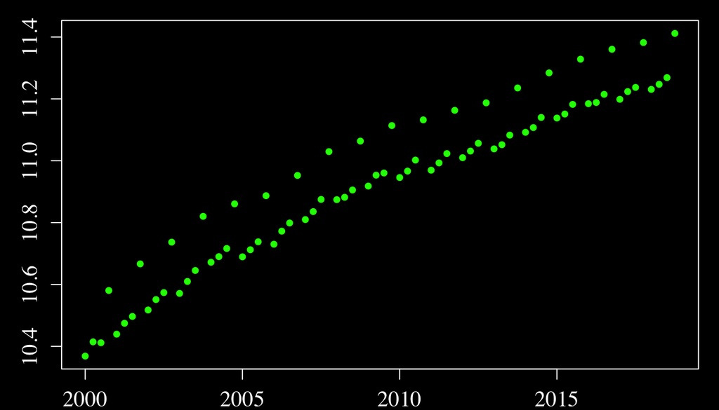

## Trend function for $Y_t = \log\text{Retail Sales}$:

$$\begin{align}
Y_t &= \beta_0 + \beta_1 \text{Time}_t + \beta_2 \text{TimePostGFC}_t \\
& \qquad + \delta_1 Q_{1,t} + \delta_2 Q_{2,t} + \delta_3 Q_{3,t} + Z_t
\end{align}$$

where
$$\begin{align}
&\text{TimePostGFC}_t \\
&\quad = (\text{Time}_t-2008.5)\times 1(\text{Time}_t>2008.5)
\end{align}$$

How to test for a unit root in $Z_t$?

## log of Retail Sales, 2000q1 - 2018q4

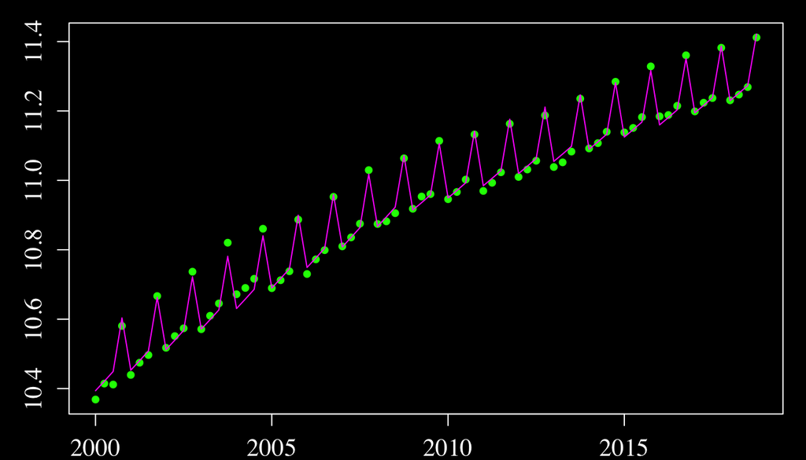

## Deviations from trend function: $\widehat{Z}_t$

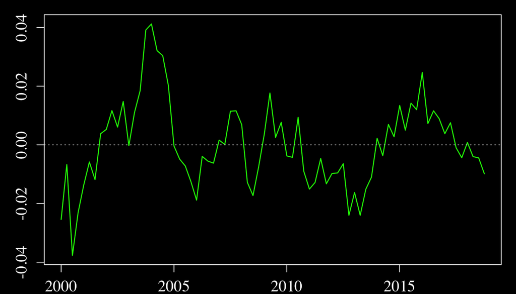

## Trend function for $Y_t = \log\text{Retail Sales}$:

$$\begin{align}
Y_t &= \beta_0 + \beta_1 \text{Time}_t + \beta_2 \text{TimePostGFC}_t \\
& \qquad + \delta_1 Q_{1,t} + \delta_2 Q_{2,t} + \delta_3 Q_{3,t} + Z_t
\end{align}$$

- ${\color{Apricot}{\textsf{ur.df}}}$ and ${\color{Apricot}{\textsf{qunitroot}}}$ do not allow for custom trend functions

## Trend function for $Y_t = \log\text{Retail Sales}$:

$$\begin{align}
Y_t &= \beta_0 + \beta_1 \text{Time}_t + \beta_2 \text{TimePostGFC}_t \\
& \qquad + \delta_1 Q_{1,t} + \delta_2 Q_{2,t} + \delta_3 Q_{3,t} + Z_t
\end{align}$$

- ${\color{Apricot}{\textsf{ur.df}}}$ and ${\color{Apricot}{\textsf{qunitroot}}}$ do not allow for custom trend functions
- We need to **calculate the ADF test** allowing for this trend function.
- We need to find the **appropriate critical value** for this trend function.

$$\large{\textbf{What is a critical value anyway?}}$$

## Components of a generic hypothesis test

- Hypotheses: $H_0$ vs $H_1$
- Significance level $\alpha$
- A test statistic $T_n$
- A decision rule such as “reject ${\color{yellow}{H_0}}$ if ${\color{yellow}{T_n < c_\alpha}}$”

## Components of a generic hypothesis test

- Hypotheses: $H_0$ vs $H_1$
- Significance level $\alpha$
- A test statistic $T_n$
- A decision rule such as “reject ${\color{yellow}{H_0}}$ if ${\color{yellow}{T_n < c_\alpha}}$”  
  (or “reject ${\color{yellow}{H_0}}$ if ${\color{yellow}{T_n > c_\alpha}}$”  
  or “reject ${\color{yellow}{H_0}}$ if ${\color{yellow}{|T_n| > c_\alpha}}$”)

## Components of a generic hypothesis test

- A decision rule such as “reject $H_0$ if $T_n < {\color{magenta}{c_\alpha}}$”

Critical value with significance level ${\color{magenta}{\alpha}}:$

$$P( T_n < {\color{magenta}{c_\alpha}} \: | \: H_0 \text{ true})
= {\color{magenta}{\alpha}}$$

## Components of a generic hypothesis test

- A decision rule such as “reject ${\color{yellow}{H_0}}$ if ${\color{yellow}{T_n < c_\alpha}}$”

Critical value with significance level $\alpha:$

$$P( {\color{yellow}{T_n < c_\alpha}} \: | \:
{\color{cyan}{H_0 \text{ true}}})
= \alpha$$

- Reject ${\color{yellow}{H_0}}$ when ${\color{cyan}{H_0}}$ is true = Type 1 Error

## Components of a generic hypothesis test

- A decision rule such as “reject $H_0$ if $T_n < c_\alpha$”

Critical value with significance level $\alpha:$

$${\color{lime}{P}}( {\color{yellow}{T_n < c_\alpha}} \: | \:
{\color{cyan}{H_0 \text{ true}}})
= \alpha$$

- Frequentist probability: proportion of samples in which ${\color{yellow}{H_0}}$ is rejected in repeated draws from the population distribution when ${\color{cyan}{H_0}}$ is true.
- We can simulate this probability!

$$\large{\textbf{Example: simulation of}}$$
$$\large{\textbf{ADF critical value}}$$

## Simulated draw from a random walk

```r
Y <- arima.sim(n=100,
      model=list(order=c(0,1,0)))
```

```
Time Series:
Start = 0
End = 100
Frequency = 1
  [1]  0.000  1.371  0.806  1.169  1.802
  [6]  2.207  2.100  3.612  3.517  5.536
 [11]  5.473  6.778  9.064  7.676  7.397
 [16]  7.264  7.899  7.615  4.959  2.518
 [21]  3.838  3.532  1.750  1.579  2.793
 [26]  4.688  4.258  4.001  2.238  2.698
 [31]  2.058  2.513  3.218  4.253  3.644
 [36]  4.149  2.432  1.648  0.797 -1.618
 [41] -1.581 -1.375 -1.736 -0.978 -1.705
 [46] -3.073 -2.640 -3.452 -2.008 -2.439
 [51] -1.784 -1.462 -2.246 -0.670 -0.027
 [56]  0.063  0.339  1.019  1.109 -1.885
 [61] -1.600 -1.967 -1.782 -1.200  0.200
 [66] -0.527  0.775  1.111  2.150  3.070
 [71]  3.791  2.748  2.658  3.281  2.328
 [76]  1.785  2.366  3.134  3.598  2.712
 [81]  1.612  3.125  3.383  3.471  3.351
 [86]  2.156  2.768  2.551  2.368  3.302
 [91]  4.123  5.516  5.039  5.690  7.081
 [96]  5.970  5.109  3.978  2.518  2.598
[101]  3.251
```

## Simulated draw from a random walk

```r
Y <- arima.sim(n=100,
      model=list(order=c(0,1,0)))
```

```
Time Series:
Start = 0
End = 100
Frequency = 1
  [1]  0.000  1.371  0.806  1.169  1.802
  [6]  2.207  2.100  3.612  3.517  5.536
 [11]  5.473  6.778  9.064  7.676  7.397
 [16]  7.264  7.899  7.615  4.959  2.518
 [21]  3.838  3.532  1.750  1.579  2.793
 [26]  4.688  4.258  4.001  2.238  2.698
 [31]  2.058  2.513  3.218  4.253  3.644
 [36]  4.149  2.432  1.648  0.797 -1.618
 [41] -1.581 -1.375 -1.736 -0.978 -1.705
 [46] -3.073 -2.640 -3.452 -2.008 -2.439
 [51] -1.784 -1.462 -2.246 -0.670 -0.027
 [56]  0.063  0.339  1.019  1.109 -1.885
 [61] -1.600 -1.967 -1.782 -1.200  0.200
 [66] -0.527  0.775  1.111  2.150  3.070
 [71]  3.791  2.748  2.658  3.281  2.328
 [76]  1.785  2.366  3.134  3.598  2.712
 [81]  1.612  3.125  3.383  3.471  3.351
 [86]  2.156  2.768  2.551  2.368  3.302
 [91]  4.123  5.516  5.039  5.690  7.081
 [96]  5.970  5.109  3.978  2.518  2.598
[101]  3.251
```

$$\begin{align}
{\color{magenta}{\Large\uparrow}}\qquad\quad \\
{\color{magenta}{\text{ARIMA}(0,1,0)}}
\end{align}$$

## Simulated draw from a random walk

```r
Y <- arima.sim(n=100,
      model=list(order=c(0,1,0)))
```

```
Time Series:
Start = 0
End = 100
Frequency = 1
  [1]  0.000  1.371  0.806  1.169  1.802
  [6]  2.207  2.100  3.612  3.517  5.536
 [11]  5.473  6.778  9.064  7.676  7.397
 [16]  7.264  7.899  7.615  4.959  2.518
 [21]  3.838  3.532  1.750  1.579  2.793
 [26]  4.688  4.258  4.001  2.238  2.698
 [31]  2.058  2.513  3.218  4.253  3.644
 [36]  4.149  2.432  1.648  0.797 -1.618
 [41] -1.581 -1.375 -1.736 -0.978 -1.705
 [46] -3.073 -2.640 -3.452 -2.008 -2.439
 [51] -1.784 -1.462 -2.246 -0.670 -0.027
 [56]  0.063  0.339  1.019  1.109 -1.885
 [61] -1.600 -1.967 -1.782 -1.200  0.200
 [66] -0.527  0.775  1.111  2.150  3.070
 [71]  3.791  2.748  2.658  3.281  2.328
 [76]  1.785  2.366  3.134  3.598  2.712
 [81]  1.612  3.125  3.383  3.471  3.351
 [86]  2.156  2.768  2.551  2.368  3.302
 [91]  4.123  5.516  5.039  5.690  7.081
 [96]  5.970  5.109  3.978  2.518  2.598
[101]  3.251
```

$$\begin{align}
{\color{magenta}{\Large\uparrow}}\qquad \\
{\color{magenta}{\swarrow \: \text{Sample size}}}
\end{align}$$

## Simulated draw from a random walk

```r
Y <- arima.sim(n=100,
      model=list(order=c(0,1,0)))
```

```
Time Series:
Start = 0
End = 100
Frequency = 1
  [1]  0.000  1.371  0.806  1.169  1.802
  [6]  2.207  2.100  3.612  3.517  5.536
 [11]  5.473  6.778  9.064  7.676  7.397
 [16]  7.264  7.899  7.615  4.959  2.518
 [21]  3.838  3.532  1.750  1.579  2.793
 [26]  4.688  4.258  4.001  2.238  2.698
 [31]  2.058  2.513  3.218  4.253  3.644
 [36]  4.149  2.432  1.648  0.797 -1.618
 [41] -1.581 -1.375 -1.736 -0.978 -1.705
 [46] -3.073 -2.640 -3.452 -2.008 -2.439
 [51] -1.784 -1.462 -2.246 -0.670 -0.027
 [56]  0.063  0.339  1.019  1.109 -1.885
 [61] -1.600 -1.967 -1.782 -1.200  0.200
 [66] -0.527  0.775  1.111  2.150  3.070
 [71]  3.791  2.748  2.658  3.281  2.328
 [76]  1.785  2.366  3.134  3.598  2.712
 [81]  1.612  3.125  3.383  3.471  3.351
 [86]  2.156  2.768  2.551  2.368  3.302
 [91]  4.123  5.516  5.039  5.690  7.081
 [96]  5.970  5.109  3.978  2.518  2.598
[101]  3.251
```

$$\begin{align}
{\color{magenta}{\Large\leftarrow}} \: {\color{magenta}{\text{includes } Y_0=0}} \\
{\color{magenta}{\Large\swarrow}} \qquad\qquad\qquad \\
\end{align}$$

## Simulated draw from a random walk

```r
Y <- arima.sim(n=100,
      model=list(order=c(0,1,0)))[-1]
```

$$\begin{align}
{\color{magenta}{\Large\uparrow}}\qquad \\
{\color{magenta}{\text{Remove }} Y_0}
\end{align}$$

## Simulated draw from a random walk

```r
Y <- arima.sim(n=100,
      model=list(order=c(0,1,0)))[-1]
```

```
  [1]  1.371  0.806  1.169  1.802  2.207
  [6]  2.100  3.612  3.517  5.536  5.473
 [11]  6.778  9.064  7.676  7.397  7.264
 [16]  7.899  7.615  4.959  2.518  3.838
 [21]  3.532  1.750  1.579  2.793  4.688
 [26]  4.258  4.001  2.238  2.698  2.058
 [31]  2.513  3.218  4.253  3.644  4.149
 [36]  2.432  1.648  0.797 -1.618 -1.581
 [41] -1.375 -1.736 -0.978 -1.705 -3.073
 [46] -2.640 -3.452 -2.008 -2.439 -1.784
 [51] -1.462 -2.246 -0.670 -0.027  0.063
 [56]  0.339  1.019  1.109 -1.885 -1.600
 [61] -1.967 -1.782 -1.200  0.200 -0.527
 [66]  0.775  1.111  2.150  3.070  3.791
 [71]  2.748  2.658  3.281  2.328  1.785
 [76]  2.366  3.134  3.598  2.712  1.612
 [81]  3.125  3.383  3.471  3.351  2.156
 [86]  2.768  2.551  2.368  3.302  4.123
 [91]  5.516  5.039  5.690  7.081  5.970
 [96]  5.109  3.978  2.518  2.598  3.251
```

## Simulated draw from a random walk

```r
Y <- arima.sim(n=100,
      model=list(order=c(0,1,0)))[-1]
```

ARIMA$(0,1,0)$ : $\quad Y_t = Y_{t-1} + U_t$

Satisfies $H_0 : \phi_1=1$ (unit root) in  
$\qquad Y_t = \phi_1 Y_{t-1} + U_t$

## ADF test on simulated random walk

```r
Y <- arima.sim(n=100,
      model=list(order=c(0,1,0)))[-1]
ADF <- ur.df(Y, type="drift", lags=0)
```

Test equation:

```
        Estimate Std. Error t value Pr(>|t|)
drift     0.1755     0.1326  1.3236   0.1887
z.lag.1  -0.0701     0.0374 -1.8745   0.0639
```

$\qquad\qquad\qquad\qquad\qquad {\color{orange}{\uparrow}}$

Test statistic : $\qquad T_n = -1.8745$

## Repeat ADF tests on simulated random walks

```r
reps <- 1000
Tn <- matrix(nrow=reps, ncol=1)

# Repeat reps times
for (r in 1:reps){

  # Simulate random walk
  Y <- arima.sim(n=100,
      model=list(order=c(0,1,0)))[-1]

  # Carry out ADF test
  ADF <- ur.df(Y, type="drift", lags=0)
  Tn[r] <- ADF@teststat[1]
}
```

## Sampling distribution of ADF test

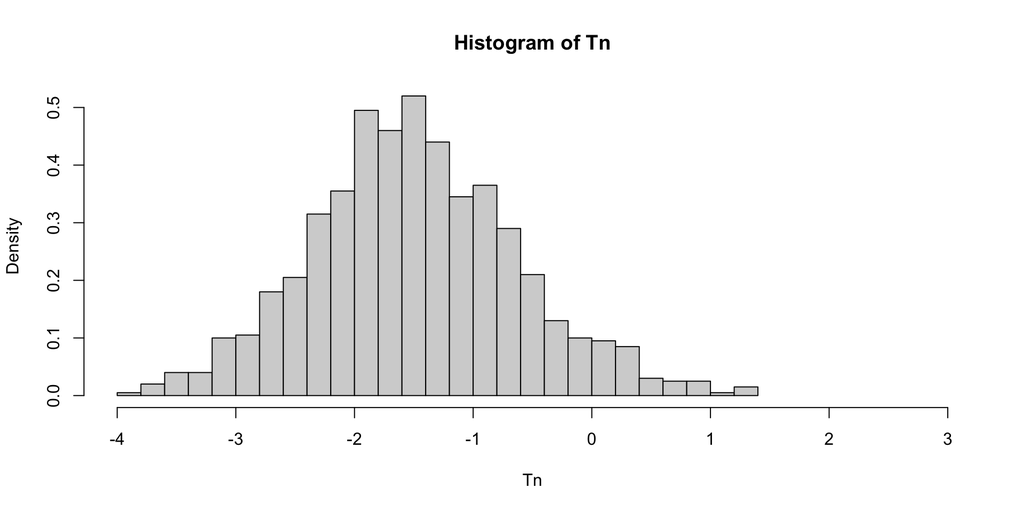

```r
hist(Tn)
```

## Sampling distribution of ADF test

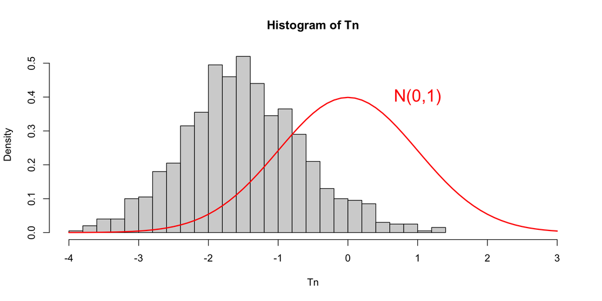

```r
hist(Tn)
```

## Simulated critical values of ADF test

```r
SignificanceLevels <- c(0.01, 0.05, 0.1)
cv_sim <- quantile(Tn,
              probs=SignificanceLevels)
```

```
            1%     5%     10%
cv_sim   -3.462 -2.894 -2.587
```

Comparison:

```r
cv_drift <- qunitroot(p=SignificanceLevels,
          N=100, trend="c", statistic="t")
```

```
            1%     5%     10%
cv_drift -3.497 -2.891 -2.582
```

$$\large{\textbf{What is a p-value anyway?}}$$

## Components of a generic hypothesis test

- Hypotheses: $H_0$ vs $H_1$
- Significance level $\alpha$
- A test statistic $T_n$
- A decision rule such as “reject ${\color{yellow}{H_0}}$ if ${\color{yellow}{T_n < c_\alpha}}$”

Suppose we calculate the test statistic to be ${\color{magenta}{t}}$.

$\:\:p\text{-value} : \quad p = P(\ {\color{yellow}{T_n <}} \:\: {\color{magenta}{t}} \: | \: H_0 \text{ true}\ )$

Decision rule: reject ${\color{yellow}{H_0}}$ if ${\color{yellow}{p<\alpha}}$.

## Simulated *p*-value of ADF test

Eg. suppose we calculate $t= {\color{magenta}{-1.8}}$.

Then $\:\: p = P(\ T_n < {\color{magenta}{-1.8}} \: | \: H_0 \text{ true}\ )$ :

```r
p_sim = mean(Tn < -1.8)
```

The proportion of the simulated statistics under $H_0$ that satisfy $T_n < -1.8$.

```
p_sim = 0.372
```

## Simulated *p*-value of ADF test

Eg. suppose we calculate $t= {\color{magenta}{-1.8}}$.

Then $\:\: p = P(\ T_n < {\color{magenta}{-1.8}} \: | \: H_0 \text{ true}\ )$ :

```r
p_sim = mean(Tn < -1.8)
```

```
p_sim = 0.372
```

Comparison:

```r
p = punitroot(-1.8, N=100, trend="c",
              statistic="t")
```

```
p     = 0.379
```

## Notes on the ADF simulation process

$$\Delta Y_t = X_t'\beta^* + \varphi Y_{t-1} +
\sum_{j=1}^{p-1} \psi_j \Delta Y_{t-j} + U_t$$

- The specification of $X_t$ matters most.
- $n$ has minor effect.
- $p$ and $\psi_1,\ldots,\psi_{p-1}$ : “asymptotically negligible”.
- Distribution of $U_t$ : “asymptotically negligible”.

## Notes on the ADF simulation process

Therefore under $H_0$ we simulate from
$$\Delta Y_t = X_t'\beta^* + \varphi Y_{t-1} +
\sum_{j=1}^{p-1} \psi_j \Delta Y_{t-j} + U_t$$

## Notes on the ADF simulation process

Therefore under ${\color{magenta}{H_0 : \varphi=0}}$ we simulate from
$$\Delta Y_t = X_t'\beta^* + {\color{magenta}{\varphi}} Y_{t-1} +
\sum_{j=1}^{p-1} \psi_j \Delta Y_{t-j} + U_t$$

## Notes on the ADF simulation process

Therefore under ${\color{magenta}{H_0 : \varphi=0}}$ we simulate from
$$\Delta Y_t = X_t'\beta^* \:\: \phantom{ + \varphi Y_{t-1}} +
\sum_{j=1}^{p-1} \psi_j \Delta Y_{t-j} + U_t$$

- $p$ and $\psi_1,\ldots,\psi_{p-1}$ : “asymptotically negligible”.

## Notes on the ADF simulation process

Therefore under $H_0 : \varphi=0$ we simulate from
$$\Delta Y_t = X_t'\beta^* \:\: \phantom{ + \varphi Y_{t-1}} +
\sum_{j=1}^{{\color{orange}{p}}-1} {\color{lime}{\psi_j}} \Delta Y_{t-j} + U_t$$

- ${\color{orange}{p}}$ and ${\color{lime}{\psi_1,\ldots,\psi_{p-1}}}$ : “asymptotically negligible”.  
  Therefore set ${\color{orange}{p=1}}$ (${\color{lime}{\psi_j=0}}$)

## Notes on the ADF simulation process

Therefore under $H_0 : \varphi=0$ we simulate from
$$\Delta Y_t = X_t'\beta^* \:\: \phantom{ + \varphi Y_{t-1} +
\sum_{j=1}^{p-1} \psi_j \Delta Y_{t-j}} + {\color{cyan}{U_t}}$$

- Distribution of ${\color{cyan}{U_t}}$ : “asymptotically negligible”.

## Notes on the ADF simulation process

Therefore under $H_0 : \varphi=0$ we simulate from
$$\Delta Y_t = X_t'\beta^* + {\color{cyan}{U_t}}$$

- Distribution of ${\color{cyan}{U_t}}$ : “asymptotically negligible”.  
  We set ${\color{cyan}{U_t \sim N(0,1)}}$.

## Notes on the ADF simulation process

Therefore under $H_0 : \varphi=0$ we simulate from
$$\Delta Y_t = X_t'{\color{magenta}{\beta^*}} + U_t, \quad U_t\sim N(0,1)$$

- The ADF test is *invariant* to ${\color{magenta}{\beta^*}}$.  
  (As long as we regress on $X_t$).

## Notes on the ADF simulation process

Therefore under $H_0 : \varphi=0$ we simulate from
$$\Delta Y_t = X_t'{\color{magenta}{\beta^*}} + U_t, \quad U_t\sim N(0,1)$$

- The ADF test is *invariant* to ${\color{magenta}{\beta^*}}$.  
  (As long as we regress on $X_t$).  
  Therefore we set ${\color{magenta}{\beta^*=0}}$.

## Notes on the ADF simulation process

Therefore under $H_0 : \varphi=0$ we simulate from
$$\Delta Y_t = U_t, \quad U_t\sim N(0,1)$$

## Summary

- Concepts of critical value and *p*-value.
- Simulation of critical/*p*-values by repeated generation from a model under $H_0$.
- Dependence of ADF critical/*p*-values on trend specification.